# Report

#### AUROPHARMA

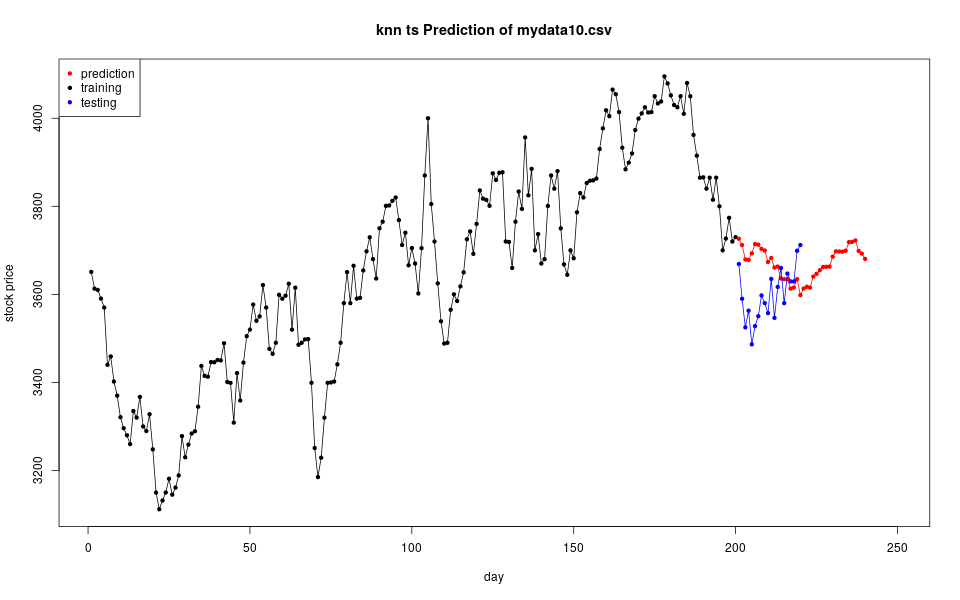

```r
knitr::include_graphics("~/Desktop/2.png")
```

#### We can see that the overall trend of the testing points is up, while the downward trend of our prediction points indicates that our model is not accurate in predicting this stock. So we need to be very careful when buying and selling this stock.

#### PEL

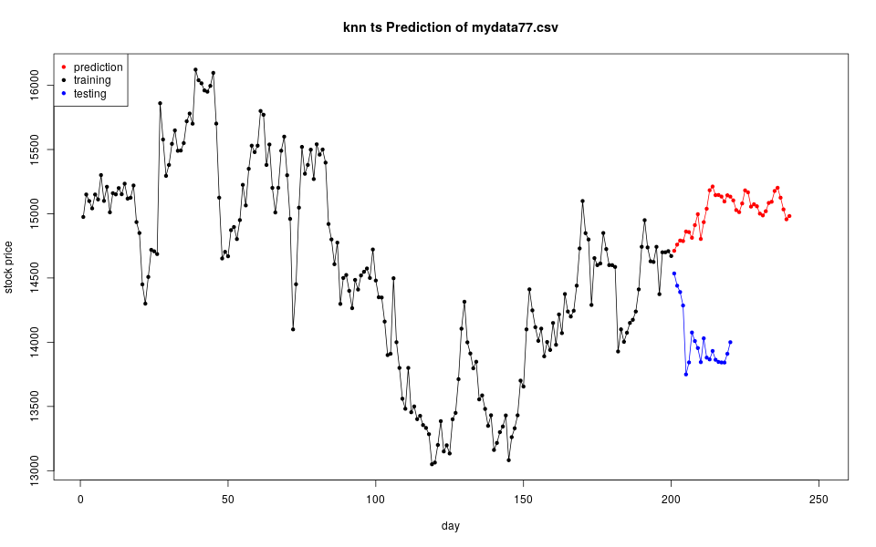

```r
knitr::include_graphics("~/Desktop/3.png")
```

## Contribution

#### Everyone participated in the presentation.

#### Code part: Zhanpeng Xu, Zheming Cao and Xilin Qiao.

#### Report part: Jiayang Wang and Yeming Wei.